# Analysis of Employee Attrition - They'll leave us; They'll leave us not

## Overview

- Introduction
- Description of Data
- Processing Vs Analysing
- Data Cleaning
- Data Analysis
  - Which department has the highest percentage of employee attrition?
  - Organization Hopping: A sign of attrition?
  - Does giving employees stock options work towards making them want to stay?
  - Model Building and Selection
  - Feature Importance Analysis
- Takeaways
- Business Recommendations
- Conclusion

## Introduction

In this notebook we are going to be analysing IBM's famous HR Attrition dataset, which has over 30 features to describe the characteristics of around 1400 employees along with a variable to indicate if they ultimately stayed at the company or left.

We have two motivating questions that drive this analysis -

- How well can we predict the likelihood of an employee quitting at a given time using information like their age, gender, experience, compensation, etc?
- What factors have a significant degree of influence on an employee's decision to quit (or stay).

**'Why do the answers to these questions matter?', you might ask..**

Employee turnover is a problem that companies ranging from small-scale to corporate have been tackling for decades now. Especially in mammoth multinational organizations with operations and projects which run on specialized-skilled manpower, this has proved to be a very costly issue/bottleneck with the costs manifesting not just in capital (training costs, signing bonuses, costs of recruiting a new candidate, and what not) but also in long-term productivity and quality of product/service.

*Many studies show that the total cost of losing an employee can range from tens of thousands of dollars to 1.5-2X annual salary* (That's too depressing a figure to display on a fancy plot).

John Bersin, an HR Expert from Deloitte, in a LinkedIn post wrote that, '*Employees are appreciating assets that produce more and more value to the organization over time, which helps explain why losing them is so costly*'.

So to answer the questions - 'Why do we need to know the factors that drive/influence an employee to leave' and 'How does the mathematical probability of an employee quitting matter when we could just follow the good old procedure of interview candidates, recruit, train, rinse and repeat all over again everytime an employee quits?' - Because a hike in costs and drop in productivity in addition to the loss of any organization's most precious resource, the employee, are absolutely undesirable.

Identifying overarching factors which make people want to quit can enable the organization to improve situations related to those factors. Predicting employee churn can be a due dilligence measure in the sense that when the data shows a list of employees with high probability of quitting, the team can find and implement ways to win them back or at the very least, begin the search for a new candidate early such that productivity is not as badly hit as when someone suddenly quits.

## The Data

We obtained the dataset from [Kaggle](https://www.kaggle.com/pavansubhasht/ibm-hr-analytics-attrition-dataset). This is a fictional data set created by IBM data scientists which consists of different factors (of both active and inactive employees) that can influence attrition.

This is data is fully tabular. It has 1470 records of employees described by 34 features along with one variable to indicate if they quit or not by 1 or 0 respectively.

The features names and their descriptions are as follows -

- Age (Numeric) - The age of the employee - Min: 18; Max: 60
- Attrition (Categorical) - A variable to indicate if the employee has quit or not {1: 'Quit', 0: 'Not Quit'}
- BusinessTravel (Categorical) - How often does the job require the employee to travel? - The categories are - Travel_Rarely, Travel_Frequently, Non-Travel
- DailyRate (Numeric) - An approximate of the employee's daily rate - Min: 102; Max: 1499
- Department (Categorical) - The department that the employee works in - Sales, Research & Development, Human Resources
- DistanceFromHome (Numeric) - Distance in miles from employee's home to office - Min: 1; Max: 29
- Education (Categorical) - Level of employee's education - {1: 'Below College', 2: 'College', 3: 'Bachelor', 4: 'Master', 5 'Doctor'}
- EducationField (Categorical) - The area that the employee has majored in - Life Sciences, Other, Medical, Marketing, Technical Degree, Human Resources
- EmployeeCount (Numeric) - An indication of the number of employees with these exact features
- EmployeeNumber (Categorical) - An identification number for the record (sort of an index)
- EnvironmentSatisfaction (Categorical) - Level of employee's satisfaction with the work environment - {1: 'Low', 2: 'Medium', 3: 'High', 4: 'Very High'}
- Gender (Categorical) - Male, Female
- HourlyRate (Numeric) - An approximation of the employee's hourly rate - Min: 30; Max: 100
- JobInvolvement (Categorical) - How involved the employee is in the job - {1: 'Low', 2: 'Medium', 3: 'High', 4: 'Very High'}
- JobLevel (Categorical) - Employee's level in the team/company heirarchy - 1, 2, 3, 4, 5 where is 1 is entry-level and 5 is executive-level
- JobRole (Categorical) - Employee's job role in the company - Sales Executive, Research Scientist, Laboratory Technician, Manufacturing Director, Healthcare Representative, Manager, Sales Representative, Research Director, Human Resources
- JobSatisfaction (Categorical) - How satisfied is the employee with the job - {1: 'Low', 2: 'Medium', 3: 'High', 4: 'Very High'}
- MaritalStatus (Categorical) - Employee's marital status - Single, Married, Divorced
- MonthlyIncome (Numeric) - An approximation of the employee's monthly income - Min: 1009; Max: 19999
- MonthlyRate (Numeric) - An approximation of the employee's gross monthly rate - Min: 2094; Max: 26999
- NumCompaniesWorked (Numeric) - Number of companies that the employee worked for in the entirety of his/her career - Min: 0; Max: 9
- Over18 (Categorical) - An indicator of whether the employee is above 18 - Y
- OverTime (Categorical) - An indicator of whether the employee is required to put in over time - Yes, No
- PercentSalaryHike (Numeric) - Average salary hike percentage for the employee - Min: 11; Max: 25
- PerformanceRating (Categorical) - Rating given for the employee's performance - {1: 'Low', 2: 'Good', 3: 'Excellent', 4: 'Outstanding'}
- RelationshipSatisfaction (Categorical) - Level of satisfaction with workplace relationships - {1: 'Low', 2: 'Medium', 3: 'High', 4: 'Very High'}
- StandardHours (Numeric) - Number of work hours per pay period - Min: 80; Max: 80
- StockOptionLevel (Categorical) - Number of stock options given to the employee - 0, 1, 2, 3
- TotalWorkingYears (Numeric) - Career length of the employee in years - Min: 0; Max: 40
- TrainingTimesLastYear (Numeric) - Number of times that the employee has undergone training in the previous year - Min: 0; Max: 6
- WorkLifeBalance (Categorical) - Level of work-life balance of the employee - {1: 'Bad', 2: 'Good', 3: 'Better', 4: 'Best'}
- YearsAtCompany (Numeric) - Number of years that the employee worked for the organization - Min: 0; Max: 40
- YearsInCurrentRole (Numeric) - Number of years that the employee has been in the current role for - Min: 0; Max: 18
- YearsSinceLastPromotion (Numeric) - Number of years since the employee's previous promotion - Min: 0; Max: 15
- YearsWithCurrManager (Numeric) - Number of years working under current manager - Min: 0; Max: 17

## Processing Vs Analysing

*For* our project, we have chosen to place more focus on data analysis than the data processing.

*Why?*

As mentioned in the introduction, our motive is to determine which factors have a general dominating influence on employee turnover and also, find accurate methods to predict likelihood of an employee quitting. The means to getting answers to these questions is through creating models using statistical learning techniques. While we will be using data processing (to prep the data for analysis), the actual focus of our project will be on the **data analysis**.

## Getting started

### Importing necessary libraries

We will be using the numpy library for key mathematical functions and pandas for manipulating our dataset.

And for prettying up the notebook and making our analysis more comprehensive, we are importing matplotlib, seaborn, and plotly for creating data visualizations.

```python
# Import libraries
    # For data manipulation
import numpy as np
import pandas as pd
    # For data visualizations
import matplotlib.pyplot as plt
import seaborn as sns
import plotly.graph_objects as go
import plotly.express as px
```

### Loading the data

For performing data analysis, before anything else, we need.. data. So let's get that and load it into a pandas dataframe.

```python
df = pd.read_csv(r"IBM_HR_Data.csv")
# df.head()
```

### The first step in any data analysis project (after importing libraries and loading the dataset, that is)

## DATA CLEANING

[This Ultimate Guide to Data Cleaning](https://towardsdatascience.com/the-ultimate-guide-to-data-cleaning-3969843991d4) and the Wikipedia article on [Data Cleansing](https://en.wikipedia.org/wiki/Data_cleansing) provide a tangible roadmap to data cleaning. Here is the summary -

- Checking the data quality
  - Are all the variables of the appropriate data type?
  - Are there any outliers in the data? Is one of the employees a 1000 years old?
  - Mandatory constraints - certain columns can't be empty - we definitely don't want columns like Gender and MonthlyIncome to be missing any data.
  - Unique constraints - a field or a combination of fields must be unique in the dataset
- Accuracy
  - Is the data valid? Is there someone with a TotalWorkingYears = 0 have a JobLevel of 5?
- Completeness and Consistency
  - Are there any duplicate records?
  - Are there any missing values?
  - Are there any inconsistencies in the data in each column?

So let's find out the following -

- The data type of each column - is it the appropriate data type?
- The number of NA's in each column
- The number of duplicate rows
- The summary statistics of the columns with numerical data
- The unique values in the categorical columns (for identifying inconsistencies)

```python
# Finding the number of values in each column and datatypes
df.info()
```

```
<class 'pandas.core.frame.DataFrame'>
RangeIndex: 1470 entries, 0 to 1469
Data columns (total 35 columns):
Age                         1470 non-null int64
Attrition                   1470 non-null object
BusinessTravel              1470 non-null object
DailyRate                   1470 non-null int64
Department                  1470 non-null object
DistanceFromHome            1470 non-null int64
Education                   1470 non-null int64
EducationField              1470 non-null object
EmployeeCount               1470 non-null int64
EmployeeNumber              1470 non-null int64
EnvironmentSatisfaction     1470 non-null int64
Gender                      1470 non-null object
HourlyRate                  1470 non-null int64
JobInvolvement              1470 non-null int64
JobLevel                    1470 non-null int64
JobRole                     1470 non-null object
JobSatisfaction             1470 non-null int64
MaritalStatus               1470 non-null object
MonthlyIncome               1470 non-null int64
MonthlyRate                 1470 non-null int64
NumCompaniesWorked          1470 non-null int64
Over18                      1470 non-null object
OverTime                    1470 non-null object
PercentSalaryHike           1470 non-null int64
PerformanceRating           1470 non-null int64
RelationshipSatisfaction    1470 non-null int64
StandardHours               1470 non-null int64
StockOptionLevel            1470 non-null int64
TotalWorkingYears           1470 non-null int64
TrainingTimesLastYear       1470 non-null int64
WorkLifeBalance             1470 non-null int64
YearsAtCompany              1470 non-null int64
YearsInCurrentRole          1470 non-null int64
YearsSinceLastPromotion     1470 non-null int64
YearsWithCurrManager        1470 non-null int64
dtypes: int64(26), object(9)
memory usage: 402.0+ KB
```

**Observations**

- There are no null values in any of the columns
- The data types make sense but categorical variables like Department, EducationField, JobRole, MaritalStatus can be converted to the category data type.

This data has several categorical variables like JobLevel and JobSatisfaction which are ordinal in nature. We must ensure that there is a quantifiable differentiation that makes sense between any two levels for such variables.

So let's transform some of the categorical variables to the category data type

```python
# Convert Department, EducationField, JobRole, MaritalStatus to category
df['Department'] = df['Department'].astype('category')
df['EducationField'] = df['EducationField'].astype('category')
df['JobRole'] = df['JobRole'].astype('category')
df['MaritalStatus'] = df['MaritalStatus'].astype('category')
```

**Setting an Index**

Before moving further into processing, let's choose a column to set as the index. We have a column called EmployeeNumber which is a unique identification number for each employee. It looks like the ideal candidate for an index. Let's check if there are 1470 unique values in this column before setting it as the index.

```python
# Checking for number of unique values in EmployeeNumber
df['EmployeeNumber'].nunique()
```

```
1470
```

EmployeeNumber it is!

```python
# Setting EmployeeNumber column as index
df = df.set_index('EmployeeNumber')
```

**Moving on..**

We wanted to find out if there are any duplicate rows in the data. While the number of unique values for EmployeeNumber is sufficient evidence enough, let's quickly find out anyway if we are overlooking anything -

```python
# Finding the number of duplicate rows
# Creating a proxy to drop duplicates
df1 = df
df1.drop_duplicates(inplace = True)
# Number of duplicates
df.shape[0] - df1.shape[0]
```

```
0
```

There are no duplicate rows. That's a relief. We want all the data we can get.

**The Numerical Columns - Summary Statistics**

```python
# Putting all the numerical column variables names together in a list

num_cols = ['Age', 'DailyRate', 'DistanceFromHome', 'Education',
            'EmployeeCount', 'EnvironmentSatisfaction', 'HourlyRate',
            'JobInvolvement', 'JobLevel', 'JobSatisfaction', 'MonthlyIncome',
            'MonthlyRate', 'NumCompaniesWorked', 'PercentSalaryHike', 'PerformanceRating',
           'RelationshipSatisfaction', 'StandardHours', 'StockOptionLevel', 'TotalWorkingYears',
           'TrainingTimesLastYear', 'WorkLifeBalance', 'YearsAtCompany',
            'YearsInCurrentRole', 'YearsSinceLastPromotion', 'YearsWithCurrManager']

df[num_cols].describe()
```

|  | Age | DailyRate | DistanceFromHome | Education | EmployeeCount | EnvironmentSatisfaction | HourlyRate | JobInvolvement | JobLevel | JobSatisfaction | ... | RelationshipSatisfaction | StandardHours | StockOptionLevel | TotalWorkingYears | TrainingTimesLastYear | WorkLifeBalance | YearsAtCompany | YearsInCurrentRole | YearsSinceLastPromotion | YearsWithCurrManager |
| --- | --- | --- | --- | --- | --- | --- | --- | --- | --- | --- | --- | --- | --- | --- | --- | --- | --- | --- | --- | --- | --- |
| count | 1470.000000 | 1470.000000 | 1470.000000 | 1470.000000 | 1470.0 | 1470.000000 | 1470.000000 | 1470.000000 | 1470.000000 | 1470.000000 | ... | 1470.000000 | 1470.0 | 1470.000000 | 1470.000000 | 1470.000000 | 1470.000000 | 1470.000000 | 1470.000000 | 1470.000000 | 1470.000000 |
| mean | 36.923810 | 802.485714 | 9.192517 | 2.912925 | 1.0 | 2.721769 | 65.891156 | 2.729932 | 2.063946 | 2.728571 | ... | 2.712245 | 80.0 | 0.793878 | 11.279592 | 2.799320 | 2.761224 | 7.008163 | 4.229252 | 2.187755 | 4.123129 |
| std | 9.135373 | 403.509100 | 8.106864 | 1.024165 | 0.0 | 1.093082 | 20.329428 | 0.711561 | 1.106940 | 1.102846 | ... | 1.081209 | 0.0 | 0.852077 | 7.780782 | 1.289271 | 0.706476 | 6.126525 | 3.623137 | 3.222430 | 3.568136 |
| min | 18.000000 | 102.000000 | 1.000000 | 1.000000 | 1.0 | 1.000000 | 30.000000 | 1.000000 | 1.000000 | 1.000000 | ... | 1.000000 | 80.0 | 0.000000 | 0.000000 | 0.000000 | 1.000000 | 0.000000 | 0.000000 | 0.000000 | 0.000000 |
| 25% | 30.000000 | 465.000000 | 2.000000 | 2.000000 | 1.0 | 2.000000 | 48.000000 | 2.000000 | 1.000000 | 2.000000 | ... | 2.000000 | 80.0 | 0.000000 | 6.000000 | 2.000000 | 2.000000 | 3.000000 | 2.000000 | 0.000000 | 2.000000 |
| 50% | 36.000000 | 802.000000 | 7.000000 | 3.000000 | 1.0 | 3.000000 | 66.000000 | 3.000000 | 2.000000 | 3.000000 | ... | 3.000000 | 80.0 | 1.000000 | 10.000000 | 3.000000 | 3.000000 | 5.000000 | 3.000000 | 1.000000 | 3.000000 |
| 75% | 43.000000 | 1157.000000 | 14.000000 | 4.000000 | 1.0 | 4.000000 | 83.750000 | 3.000000 | 3.000000 | 4.000000 | ... | 4.000000 | 80.0 | 1.000000 | 15.000000 | 3.000000 | 3.000000 | 9.000000 | 7.000000 | 3.000000 | 7.000000 |
| max | 60.000000 | 1499.000000 | 29.000000 | 5.000000 | 1.0 | 4.000000 | 100.000000 | 4.000000 | 5.000000 | 4.000000 | ... | 4.000000 | 80.0 | 3.000000 | 40.000000 | 6.000000 | 4.000000 | 40.000000 | 18.000000 | 15.000000 | 17.000000 |

8 rows × 25 columns

From the above summary statistics, there are a few variables with standard deviation that is equal to zero. This means that the values in this variable are pretty much the same for all employees. So we can drop these columns - EmployeeCount and StandardHours.

```python
# Dropping EmployeeCount and StandardHours
df = df.drop(['EmployeeCount', 'StandardHours'], axis = 1)
```

**How clean are each of the columns?**

To see how clean our data is, we need to look at the unique values present in each columns.

```python
# A loop to print the unique values and their corresponding counts for each variable
# for col in df:
#     print(col)
#     print(df[col].unique())
```

The columns look clean. However, for modeling purposes, let's look at a few columns.

```python
# Create isMale column
df['isMale'] = np.where(df['Gender'] == 'Male', 1, 0)
# Drop Gender and Over18
df = df.drop(['Gender', 'Over18'], axis = 1)
# Transform BusinessTravel
df['BusinessTravel'] = np.where(df['BusinessTravel'] == 'Non-Travel', 0, np.where(df['BusinessTravel'] == 'Travel_Rarely', 1, 0))
# Transform Attrition and OverTime
df['Attrition'] = np.where(df['Attrition'] == 'Yes', 1, 0)
df['OverTime'] = np.where(df['OverTime'] == 'Yes', 1, 0)
```

**Binning**

There are a few numerical columns with wide ranges and variances. These are -

- Age
- DistanceFromHome
- TotalWorkingYears
- YearsAtCompany
- YearsInCurrentRole
- YearsSinceLastPromotion
- YearsWithCurrManager

Once the 'Age_Group' column is created, we can remove the 'Age' column.

```python
# Creating Age_Group
df['Age_Group'] = np.where((df['Age'] >= 18) & (df['Age'] < 30), 'Millenial',
                           np.where((df['Age'] >= 30) & (df['Age'] < 36), 'Young',
                           np.where((df['Age'] >= 36) & (df['Age'] < 43), 'Middle_Age', 'Old')))
# Convert Age_Group columnn to categorical
df['Age_Group'] = df['Age_Group'].astype('category')
# Drop the Age colum
df = df.drop(['Age'], axis = 1)
```

A similar approach can be taken for transforming the DistanceFromHome column. Using the quantiles, we can create an ordinal variable where,

- 1: Very far
- 2: Far
- 3: Manageable distance
- 4: Close

(Picking a reverse scale - 1 is most undesirable and 4 is ideal)

```python
# Transforming DistanceFromHome
df['DistanceFromHome'] = np.where((df['DistanceFromHome'] >= 1) & (df['DistanceFromHome'] < 2), 4,
                           np.where((df['DistanceFromHome'] >= 2) & (df['DistanceFromHome'] < 7), 3,
                           np.where((df['DistanceFromHome'] >= 7) & (df['DistanceFromHome'] < 14), 2, 1)))
```

**Where's the money**

There are four columns in the dataset related to the employee's pay - MonthlyIncome, MonthlyRate, DailyRate, HourlyRate. To keep things reasonably simple, let's just use one variable for employee pay. We've decided to use MonthlyIncome as it is a relatively more commonly used metric for compensation. Let's drop the rest.

```python
# Drop MonthlyRate, DailyRate, and HourlyRate
df = df.drop(['MonthlyRate', 'DailyRate', 'HourlyRate'], axis = 1)
```

## Correlations

We have condensed our dataset by performing some cleaning and some feature engineering. Using the remaining features from the initial dataset as well as the ones we created, let's see the correlation matrix and see if any features are strongly correlated.

```python
corrs = df.corr()

fig = px.imshow(corrs,
                x=list(corrs.columns),
                y=list(corrs.index), width = 900, height = 800
               )
fig.show()
```

[interactive chart not shown]

**Observations**

This figure indicates the *significantly high* correlation between

- MonthlyIncome and JobLevel (the correlation is almost 1!)
- TotalWorkingYears and JobLevel
- MonthlyIncome and TotalWorkingYears
- PercentSalaryHike and PerformanceRating (obviously)

### So now that we've sufficiently prepped our data, let's dive into the data analysis.

## Data Analysis

We first start off by using some data manipulation to extract insights for some initial questions and assumptions with regard to this data.

### 1. Which department has the highest percentage of employee attrition?

This data helps a company gain a high-level of overview of which departments need to be given more attention in terms of attrition.

```python
department_grouped = df.groupby(['Department','Attrition'])['YearsInCurrentRole'].count().unstack()
department_grouped = department_grouped.apply(lambda x: x/department_grouped.sum(axis=1)).sort_values(1,ascending=False)
department_grouped
```

| Attrition Department | 0 | 1 |
| --- | --- | --- |
| Sales | 0.793722 | 0.206278 |
| Human Resources | 0.809524 | 0.190476 |
| Research & Development | 0.861602 | 0.138398 |

*Further, does the higher level of attrition in specific departments have anything to do with the average salary hike?*

```python
percenthike = df.groupby(["Department"])['PercentSalaryHike'].mean()
percenthike
```

```
Department
Human Resources           14.761905
Research & Development    15.291363
Sales                     15.096413
Name: PercentSalaryHike, dtype: float64
```

The Sales Department has the highest rate of attrition.

Why could this be? One assumption is that **generally, it is hard to get a promotion working in the sales department.**

To test this assumption, let's check the relationship between Department and YearsInCurrentRole, YearsSinceLastPromotion, and YearWithCurrManager.

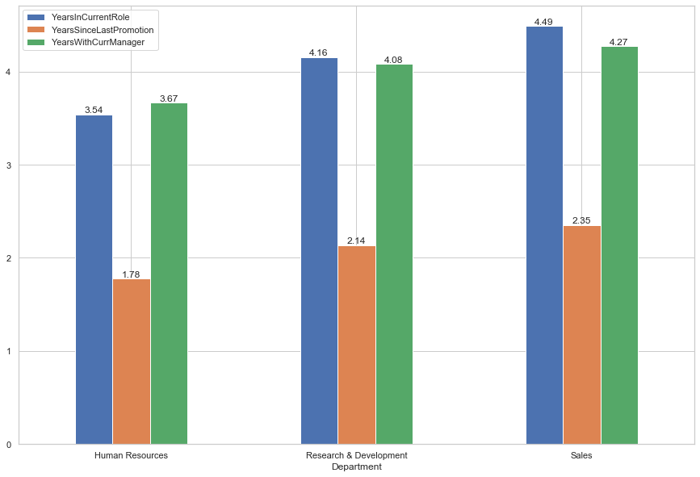

```python
sns.set(rc={'figure.figsize':(10,5)},style='whitegrid')
grouped2 = df.groupby(['Department'])[['YearsInCurrentRole', 'YearsSinceLastPromotion', 'YearsWithCurrManager']].mean().plot.bar(figsize=(15,10))
plt.xticks(rotation=0)
for p in grouped2.patches:
    height = p.get_height()
    grouped2.annotate('{}'.format(str(round(height,2))),xy=(p.get_x() + p.get_width() / 2, height), ha='center', va='bottom')
```

Based on these numbers, it is definitely clear that the Sales department has the highest average YearsInCurrentRole and YearsSinceLastPromotion and therefore could attribute to the relatively higher level of attrition. So we could say that our assumption has indeed been right.

### 2. Organization Hopping: Are employees who worked at more companies more likely to leave IBM over those with less of such company switches?

While an answer to this question might seem intuitive, it always makes sense to make the data speak and confirm (or refute) our assumptions.

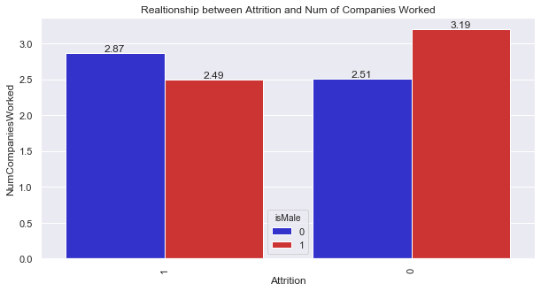

```python
sns.set()

plt.figure()

ax = sns.barplot(data=df, x="Attrition", y="NumCompaniesWorked", hue="isMale", palette=['blue', 'red', 'yellow', 'grey'], saturation=0.6,ci=None)

#Customise some display properties
ax.set_title('Realtionship between Attrition and Num of Companies Worked')
ax.set_ylabel('NumCompaniesWorked')
ax.set_xlabel('Attrition')
ax.set_xticklabels(df["Attrition"].unique().astype(str), rotation='vertical')

for p in ax.patches:
    height = p.get_height()
    ax.annotate('{}'.format(str(round(height,2))),xy=(p.get_x() + p.get_width() / 2, height), ha='center', va='bottom')
plt.show()
```

### 3. Does giving employees stock options work towards making them want to stay?

This will be interesting to see because companies usually offer stock options as an incentive for promising employees to stay. Let's plot and find out.

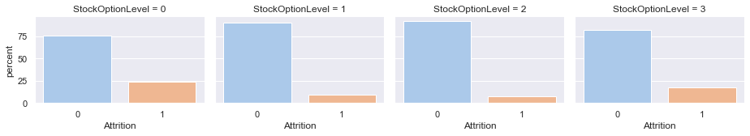

```python
x,y = 'StockOptionLevel', 'Attrition'

df1 = df.groupby(x)[y].value_counts(normalize=True)
df1 = df1.mul(100)
df1 = df1.rename('percent').reset_index()

g = sns.catplot(x="Attrition", y="percent", col="StockOptionLevel", col_wrap=4,
                data=df1, kind = 'bar',
                height=2.5, aspect=1.3, palette = "pastel", ci=None)
```

This plot has some expected and unexpected information.

- Expected: The attrition rate is higher among employees with no stock option (understandable)
- Unexpected: The attrition rate is also higher for employees with the most number of stock options out of all four groups. That is interesting. It could be because these candidates are very highly qualified and sought-after. Let's take a closer look at the data to get a better idea. It might be the case that most of these people with the highest stock options offered are in a tech role/department.

```python
gg = df[df['StockOptionLevel'] == 3].groupby(['JobRole', 'Attrition'])['Education'].count().unstack()
gg = gg.apply(lambda x: x/gg.sum(axis=1))
gg
```

| Attrition JobRole | 0 | 1 |
| --- | --- | --- |
| Healthcare Representative | 0.875000 | 0.125000 |
| Human Resources | 0.500000 | 0.500000 |
| Laboratory Technician | 0.900000 | 0.100000 |
| Manager | 1.000000 | 0.000000 |
| Manufacturing Director | 1.000000 | 0.000000 |
| Research Director | 1.000000 | 0.000000 |
| Research Scientist | 0.777778 | 0.222222 |
| Sales Executive | 0.777778 | 0.222222 |
| Sales Representative | 0.333333 | 0.666667 |

We have been *right to an extent*. Ten out of the people who left despite having significant stock options are working in tech roles. But we must also note that most of the employees who have been offered highest stock options are the ones working in tech.

Going by proportions, 50% of the employees working in Human Resources left despite being offered high level of stock options. 67% of Sales Reps also left similarly. This shows that companies should work upon their recruiting strategies especially with respect to offering stock.

### 4. Predicting the Probablity of Attrition

Here is the actual fun part of the data analysis. We set up a bunch of regressors and classifiers to predict whether the employees are to quit there jobs or not (1 or 0). Here are the steps and technologies we used to identify the model which can give us the most accurate predictions of attrition likelihood.

- Split the dataset in to training and validation dataset
- Building basic models
  - Baseline
  - Logistic regression (lasso and ridge)
  - RandomForest
  - LightGBM
  - SVM
- Tuning
  - GridSearchCV
  - RandomizedSearchCV
- Model selection

#### Import necessary packages

```python
from sklearn.metrics import mean_squared_error,accuracy_score,recall_score,confusion_matrix
from sklearn.model_selection import KFold, cross_val_score, train_test_split, GridSearchCV, RandomizedSearchCV
from sklearn.ensemble import RandomForestRegressor,RandomForestClassifier
from sklearn.linear_model import LogisticRegression
from sklearn import svm
from sklearn import metrics

import lightgbm as lgb
import matplotlib.pyplot as plt  # Matlab-style plotting
import seaborn as sns

color = sns.color_palette()
sns.set_style('whitegrid')
```

#### Baseline Model

The purpose of a baseline is in fact what its name suggests. The baseline model essentially gives us a minimum threshold on accuracy such that whatever models we build, we ensure that the accuracy beats the baseline. A baseline model could be as simple as classifying all the records as the majority class. Let's look at the accuracy in that case.

```python
print(df["Attrition"].value_counts())
#The majority class in our data is No Attrtion.
acc_baseline = (df["Attrition"].value_counts().max()/len(df["Attrition"]))*100
print("The Baseline accuracy for our model is: " +str(acc_baseline) + "%")
```

```
0    1233
1     237
Name: Attrition, dtype: int64
The Baseline accuracy for our model is: 83.87755102040816%
```

We have our work cut out for us. We should now aim to build models that can given an accuracy that is > 83.8%

#### Train-Test Split

In order to build and then test the accuracy of our model, we split our data into train and test sets. We make a random split so as to avoid any intentional/unintentional imbalance in the target variable data.

```python
df_dum = pd.get_dummies(df)
```

```python
X_train, X_test, y_train, y_test = train_test_split(df_dum.drop('Attrition',axis=1), df['Attrition'], random_state=123, train_size=0.7)
```

#### Modeling and Tuning

With our train and test data, we shall build a logistic regression model and see how it performs on the test set.

We shall try out logistic regression with both ridge and lasso penalties.

*Logistic Regression with Lasso and Ridge Penalties*

```python
#lasso
lasso = LogisticRegression(penalty = 'l1',solver='liblinear')

parameters = [1e-15, 1e-10, 1e-8, 1e-4, 1e-3,1e-2, 1, 5, 10, 20]
accuracy_lasso =[]

for a in parameters:
    lasso.set_params(C = 1/a)
    lasso.fit(X_train,y_train)
    lr_probs = lasso.predict_proba(X_test)
    lr_probs = lr_probs[:, 1]
    fpr, tpr, thresholds = metrics.roc_curve(y_test,lr_probs)
    accuracy_ls = []
    for thres in thresholds:
        y_pred = np.where(lr_probs>thres,1,0)
        accuracy_ls.append(metrics.accuracy_score(y_test, y_pred, normalize=True))
    accuracy_lasso.append(max(accuracy_ls))

acc_lasso = max(accuracy_lasso)
print('Accuracy with best Lasso parameters is:', acc_lasso)
```

```
Accuracy with best Lasso parameters is: 0.9206349206349206
```

We've already beat out baseline by a significant margin. But this is just the first model. Let's try out some more.

```python
#Ridge
ridge = LogisticRegression(penalty = 'l2',solver='liblinear')

parameters = [1e-15, 1e-10, 1e-8, 1e-4, 1e-3,1e-2, 1, 5, 10, 20]
accuracy_ridge =[]

for a in parameters:
    ridge.set_params(C = 1/a)
    ridge.fit(X_train,y_train)
    lr_probs = ridge.predict_proba(X_test)
    lr_probs = lr_probs[:, 1]
    fpr, tpr, thresholds = metrics.roc_curve(y_test,lr_probs)
    accuracy_ls = []
    for thres in thresholds:
        y_pred = np.where(lr_probs>thres,1,0)
        accuracy_ls.append(metrics.accuracy_score(y_test, y_pred, normalize=True))
    accuracy_ridge.append(max(accuracy_ls))
acc_ridge = max(accuracy_ridge)
print('Accuracy with best Lasso parameters is:', acc_ridge)
```

```
Accuracy with best Lasso parameters is: 0.9251700680272109
```

*LightGBM Regressor*

```python
lgbr = lgb.LGBMRegressor()

param_list = {
        'n_estimators':range(100,1000,100),
        'learning_rate':np.linspace(0.01,0.2,30),
        'min_data_in_leaf':range(6,26,2),
        'max_depth':range(2,30,2),
        'reg_alpha':np.linspace(0,3,10)
        }

lgb_grid = RandomizedSearchCV(lgbr,param_list,cv = 3, scoring = 'neg_mean_squared_error',n_iter=300,n_jobs = -1)

lgb_grid.fit(X_train.values,np.ravel(y_train))
lgbr_best_estimator = lgb_grid.best_estimator_
preds = lgbr_best_estimator.predict(X_test.values)
predictions_class =  np.where(preds>0.5, 1, 0)
acc_lgb = accuracy_score(y_test, predictions_class)
print('Accuracy with best LGB parameters is:', acc_lgb)
```

```
Accuracy with best LGB parameters is: 0.8979591836734694
```

*RandomForest*

```python
parameters = {'n_estimators': [100, 200, 500, 1000] ,
              'max_depth': [20,40,60,80,100,150,200,250],
              'bootstrap': [True, False]}

rf = RandomForestClassifier()
grid_rf_model = GridSearchCV(rf, parameters,scoring='accuracy', cv=5)
grid_rf_model.fit(X_train,y_train)

best_rf = grid_rf_model.best_estimator_
for p in parameters:
  print("Best '{}': {}".format(p, best_rf.get_params()[p]))
test_pred = best_rf.predict(X_test)
acc_rf = accuracy_score(y_test,test_pred)
print('Accuracy with best RandomForest parameters is:',acc_rf)
```

```
Best 'n_estimators': 500
Best 'max_depth': 100
Best 'bootstrap': False
Accuracy with best RandomForest parameters is: 0.8934240362811792
```

*Support Vector Classification*

```python
classifier=svm.SVC( kernel='rbf', C=1 ,gamma=0.2, decision_function_shape='ovo') # use ovo since we have 2 categories
classifier.fit(X_train,y_train)
acc_svc = classifier.score(X_test,y_test)

# give out the accuracy
print("Accuracy of train set：",classifier.score(X_train,y_train))
print("Accuracy of test set with SVC：",acc_svc)
```

```
Accuracy of train set： 1.0
Accuracy of test set with SVC： 0.8707482993197279
```

#### Model Selection

We built and tested a total of five machine learning models. It is time to compare their performances and pick the best one.

```python
acc_list = [acc_lgb,acc_rf,acc_svc,acc_lasso,acc_ridge]
model_list = ['LGBM','RandomForest','SVC','Lasso','Ridge']
df_acc = pd.DataFrame(acc_list,model_list,columns=['Accuracy'])
df_acc.sort_values('Accuracy',ascending=False,inplace=True)
```

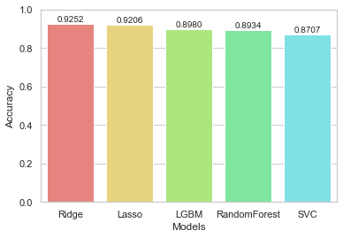

```python
sns.set(rc={'figure.figsize':(6,4)},style='whitegrid')
models = sns.barplot(df_acc.index,df_acc['Accuracy'],palette=sns.hls_palette(8, l=.7, s=.9))
for bar, sr in zip(models.patches, df_acc['Accuracy']):
    text_x = bar.get_x() + bar.get_width() / 2.0
    text_y = bar.get_height()
    text = f'{sr:.4f}'
    models.text(text_x, text_y, text,
               fontsize=10, ha='center', va='bottom')
models.set_yticks(np.arange(0.0,1.1,0.2))
plt.xlabel('Models')
plt.ylabel('Accuracy')
```

As we can see, the Rdige have highest accuracy of aboout 92.52%.

Therefore, logistic regression with ridge penalty can be used to predict the attrition likelihood of an employee with an 92.52% rate of accuracy.

### 5. Feature Importance Analysis

Using a logistic model, we are able to answer the first question - How well can we predict the likelihood of an employee quitting given information like income, age, etc?

Now, ML modeling also equips with answers to the other question - Which factors play a larger role in influencing an employee's decision to stay or quit?

By comparing different models, we selected random forest for (higher interpretability) to understand the feature importances in predicting attrition probability.

```python
names = X_train.columns
Feature = sorted(zip(map(lambda x: round(x, 4), best_rf.feature_importances_), names), reverse=True)
Best_RFdict = dict(Feature)
```

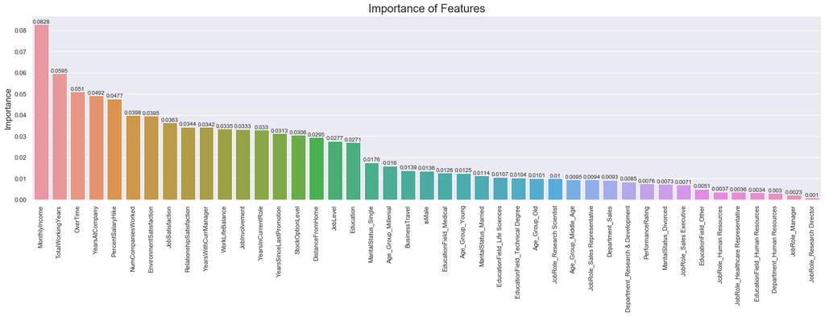

```python
sns.set(rc={'figure.figsize':(25,6)})
axis = sns.barplot(x=list(Best_RFdict.values()), y=list(Best_RFdict.keys()))
axis.set_title("Importance of Features",fontsize= 20)
axis.set_ylabel('Importance',fontsize=15)
plt.xticks(rotation='vertical');

for p in axis.patches:
    height = p.get_height()
    axis.annotate('{}'.format(height),xy=(p.get_x() + p.get_width() / 2, height), ha='center', va='bottom',fontsize=10)

display(axis)
```

The factors related to MonthlyIncome are the most important ones that could result in attrition in IBM. It is not surprising that income is the major factor in employee attrition. IBM may want to carefully decide the salary of employees to make sure they don't lose out on the talented people working in the company.

### Business Recommendations

Based on our analysis, to tackle attrition, IBM could consider implementing these strategies:

- Offering a salary hike to retain strong employees when predictions of attrition likelihood pass a certain threshold.
- Improving environment satisfaction and work-life Balance for employees by regulating overtime hours appropriately.
- The numbers (TotalWorkingYears) show that people with lesser experience are more likely to leave the company. Therefore, it is recommended to give a timely raise to people in this experience bracket or give them other benefits making it a win-win for all.

## Conclusion

The insights that we have derived from this analysis along with further exploration of employee data within an organization can aid in the better understanding of attrition and ultimately bring down the costs assosiated with this universal corporate problem.

HR Analytics is a growing field with immense potential in terms of saving money and resources for organizations. We touched upon some fundamental aspects in this area. More refinement, feature engineering, and upscaling of the data will lead to promising developments in solutions to employee turnover/attrition problems in the years to come.